# Investigation of Ford GoBike's trip data

- Introduction
- Part I - Wrangling
- Part II - Univariate Exploration
- Part III - Bivariate Exploration
- Part IV - Multivariate Exploration

## Introduction

Ford GoBike has increasingly gained popularity as one of the best bike sharing facilitator present in the United States. In this report we would focus on the customer behaviour which would help us understand our target customer. We would also be seeing the duration of trips and other essential targets such as the station's to understand more.

### Questions -

- When are most trips taken in terms of time of day, day of the week, or month of the year?
- How long does the average trip take?
- Does the above depend on if a user is a subscriber or customer?

### What is/are the main feature(s) of interest in your dataset?

Our basic aim is to find when has the most number of trips been taken , whether an average time for subscriber differs from customer , if so then what would this difference mean to us ? Hence , Duration and user_type seems to be a good start but thinking from a sales perspective we must also evaluate which station is more profitable for us. Also , from other sales persepctive we may also want to see about the type of customer on the basis of age/gender to target more customers use our service.

### What features in the dataset do you think will help support your investigation into your feature(s) of interest?

As previously mentioned , Our main feature would be

1. Station start
2. Duration
3. Station end
4. User_type

From sales perspective ,

1. Member_gender
2. Member_birth_year

### Lets see the *most* and the *least* common/popular starting stations

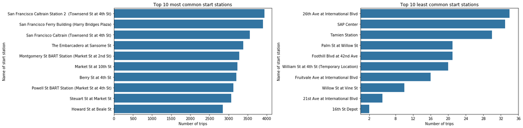

```python
base_color = sb.color_palette()[0]
fig = plt.figure(figsize = [20, 5])

# the plot on the left: Top 10 most common start stations
plt.subplot(1, 2, 1)
neighbourhood_counts = df['start_station_name'].value_counts()
neighbourhood_order = neighbourhood_counts.index
ax1 = sb.countplot(data = df, y = 'start_station_name', order = neighbourhood_order[:10], color=base_color)
plt.xlabel('Number of trips')
plt.ylabel('Name of start station')
plt.title('Top 10 most common start stations');


# the plot on the right: Top 10 least common start stations
plt.subplot(1, 2, 2)
neighbourhood_counts = df['start_station_name'].value_counts()
neighbourhood_order = neighbourhood_counts.index
ax2 = sb.countplot(data = df, y = 'start_station_name', order = neighbourhood_order[-10:], color=base_color)
plt.xticks((2,8,12,16,20,24,28,32,36))
plt.xlabel('Number of trips')
plt.ylabel('Name of start station')
plt.title('Top 10 least common start stations');
x_labels = np.arange(0, 19, 2)


fig.tight_layout();
```

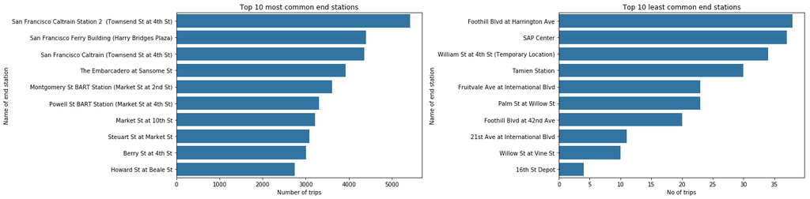

```python
fig = plt.figure(figsize = [20, 5])

# the plot on the left: Top 10 most common end stations
plt.subplot(1, 2, 1)
neighbourhood_counts = df['end_station_name'].value_counts()
neighbourhood_order = neighbourhood_counts.index
sb.countplot(data = df, y = 'end_station_name', order = neighbourhood_order[:10], color=base_color)
plt.xlabel('Number of trips')
plt.ylabel('Name of end station')
plt.title('Top 10 most common end stations');


# the plot on the right: Top 10 least common end stations
plt.subplot(1, 2, 2)
neighbourhood_counts = df['end_station_name'].value_counts()
neighbourhood_order = neighbourhood_counts.index
sb.countplot(data = df, y = 'end_station_name', order = neighbourhood_order[-10:], color=base_color)
plt.xlabel('No of trips')
plt.ylabel('Name of end station')
plt.title('Top 10 least common end stations');

fig.tight_layout()
```

### Lets see the participation in trips based on day of the week and the gender of the people

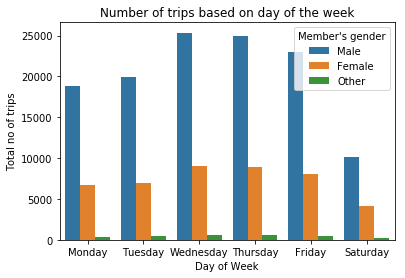

```python
# plot of Number of trips based on day of the week
df['start_day'] = df['start_time'].dt.day_name()
x_marker = ['Monday', 'Tuesday', 'Wednesday', 'Thursday','Friday', 'Saturday']
sb.countplot(data=df, x='start_day', hue='member_gender', order=x_marker);
plt.title('Number of trips based on day of the week')
plt.xlabel('Day of Week')
plt.ylabel('Total no of trips');
plt.legend(title = "Member's gender");
```

Lets see the participation in trips based on day of the week and the type of user subscription

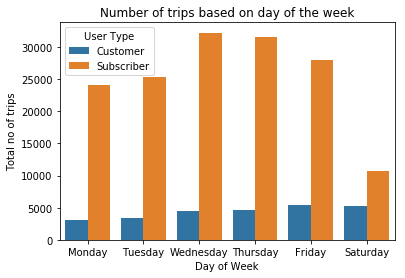

```python
# Number of trips based on day of the week
x_marker = ['Monday', 'Tuesday', 'Wednesday', 'Thursday','Friday', 'Saturday']
sb.countplot(data=df, x='start_day', hue='user_type', order=x_marker);
plt.title('Number of trips based on day of the week')
plt.xlabel('Day of Week')
plt.ylabel('Total no of trips');
plt.legend(title = "User Type");
```

One of the interesting plot could be to see behavorial aspect in terms of the day of the week. We would be able to check a certain trend

We now want to see whether the day has any impact from the above ?

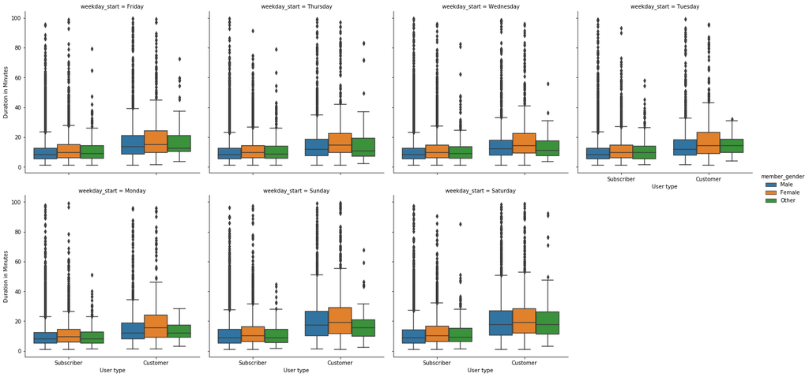

```python
# multible plots of user type with duration of trip by gender
df['weekday_start'] = df.start_time.dt.dayofweek.map(dayofweek)
g = sb.catplot(x="user_type", y="duration_min",col = 'weekday_start',hue="member_gender",col_wrap=4, kind="box",
                  data=df.query('duration_min < 100'))
g.set_xlabels('User type')
g.set_ylabels('Duration in Minutes');
```

In terms of the above figure , We can see that Male customers as well as Female customers tend to have a longer duration on Saturday and Sunday.

This particular trend can be super useful. We can expect higher duration of rides on Saturday and Sunday even though the numbers on the particular days are low.

### Now lets move to the Pair wise grid for the above variables

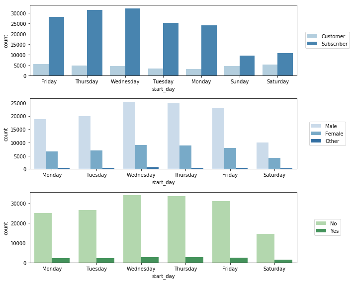

```python
fig = plt.figure(figsize = [10, 8])
df['start_day'] = df['start_time'].dt.day_name()

x_marker = ['Monday', 'Tuesday', 'Wednesday', 'Thursday','Friday', 'Saturday']

# subplot 1: start_day vs user_type
ax = plt.subplot(3, 1, 1)
sb.countplot(data = df, x = 'start_day', hue = 'user_type', palette = 'Blues')
ax.legend(loc='center', bbox_to_anchor=(1.115, 0.5))

# subplot 2: start_day vs. member_gender
ax = plt.subplot(3, 1, 2)
sb.countplot(data = df, x = 'start_day', hue = 'member_gender', palette = 'Blues', order = x_marker)
ax.legend(loc='center', bbox_to_anchor=(1.115, 0.5))

# subplot 3: start_day vs. bike_share_for_all_trip
ax = plt.subplot(3, 1, 3)
sb.countplot(data = df, x = 'start_day', hue = 'bike_share_for_all_trip', palette = 'Greens', order = x_marker)
ax.legend(loc='center', bbox_to_anchor=(1.115, 0.5))

fig.tight_layout();
```

## Conclusions

Finally I am going to conclude this report as follows :-

[output not shown]